# race and discrimination summary

xu

06 November, 2020

## blood sample summary

```
## data_blood %>% dplyr::mutate_all(as.factor)
##
##  7  Variables      2385  Observations
## -----------------------------------------------------------------------------------------------------------------------------------
## raceethnicity
##        n  missing distinct
##     2385        0        3
##
## Value      NonHwhite NonHblack  Hispanic
## Frequency       1643       436       306
## Proportion     0.689     0.183     0.128
## -----------------------------------------------------------------------------------------------------------------------------------
## lowbirthweight
##        n  missing distinct
##     2380        5        2
##
## Value          0     1
## Frequency   2131   249
## Proportion 0.895 0.105
## -----------------------------------------------------------------------------------------------------------------------------------
## high_lowbirth
##        n  missing distinct
##     2380        5        2
##
## Value          0     1
## Frequency   1848   532
## Proportion 0.776 0.224
## -----------------------------------------------------------------------------------------------------------------------------------
## discrim1
##        n  missing distinct
##     2339       46       15
##
## lowest : 0  1  2  3  4 , highest: 10 11 12 13 14
##
## Value          0     1     2     3     4     5     6     7     8     9    10    11    12    13    14
## Frequency    376   300   324   309   308   286   152   102    79    44    30    15     8     4     2
## Proportion 0.161 0.128 0.139 0.132 0.132 0.122 0.065 0.044 0.034 0.019 0.013 0.006 0.003 0.002 0.001
## -----------------------------------------------------------------------------------------------------------------------------------
## discrim2
##        n  missing distinct
```

[output cut: 13 more lines]

```
##
## Value          0     1     2     3     4     5     6
## Frequency   1147   605   279   167    86    43    10
## Proportion 0.491 0.259 0.119 0.071 0.037 0.018 0.004
## -----------------------------------------------------------------------------------------------------------------------------------
## totdiscrim2
##        n  missing distinct
##     2286       99        7
##
## lowest : 0 1 2 3 4, highest: 2 3 4 5 6
##
## Value          0     1     2     3     4     5     6
## Frequency   1906   145    92    70    43    22     8
## Proportion 0.834 0.063 0.040 0.031 0.019 0.010 0.003
## -----------------------------------------------------------------------------------------------------------------------------------
```

## whole sample and blood sample plot

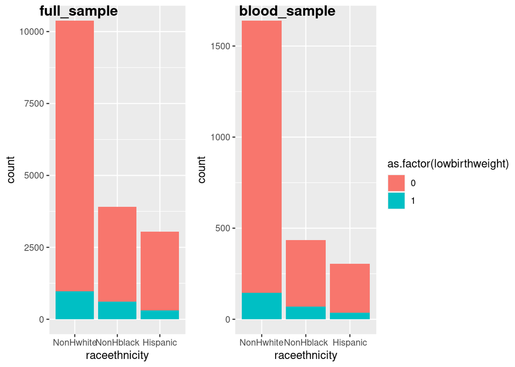

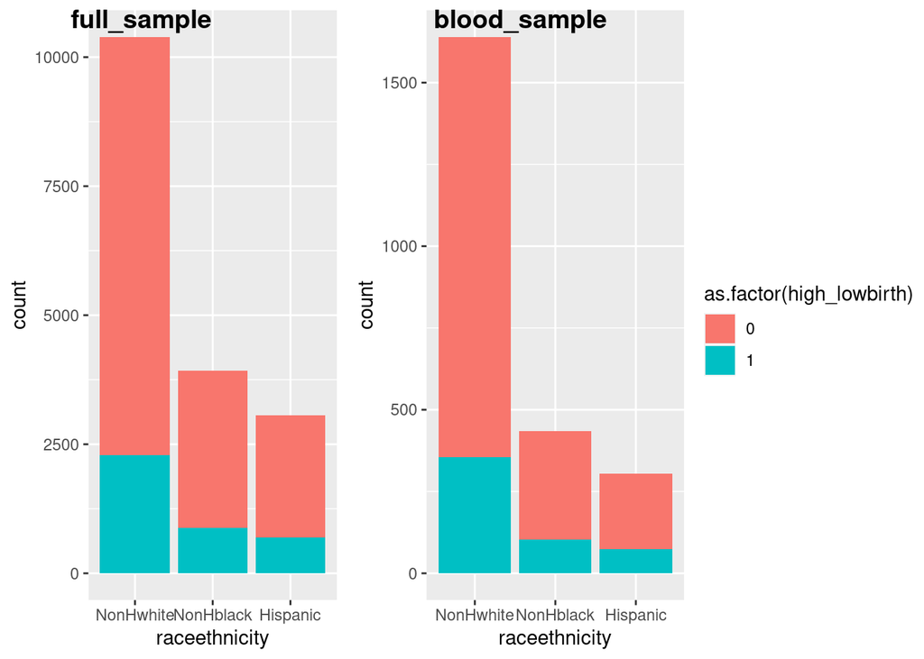

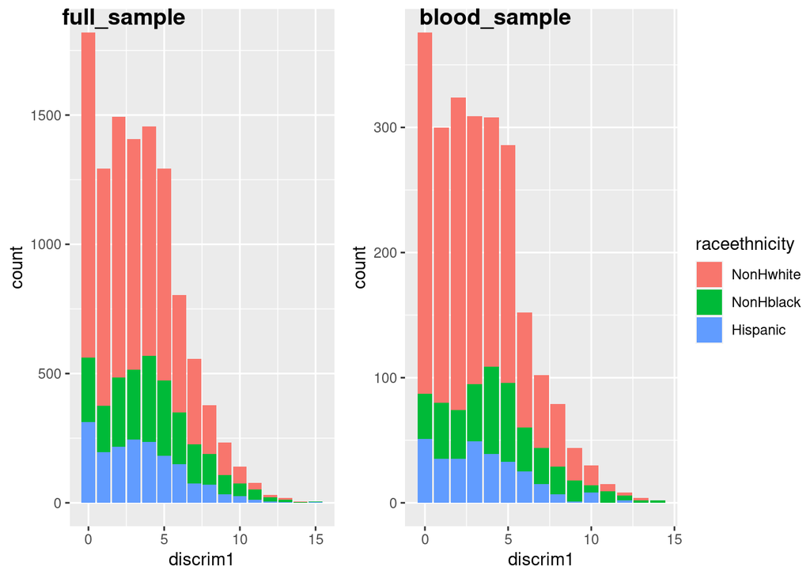

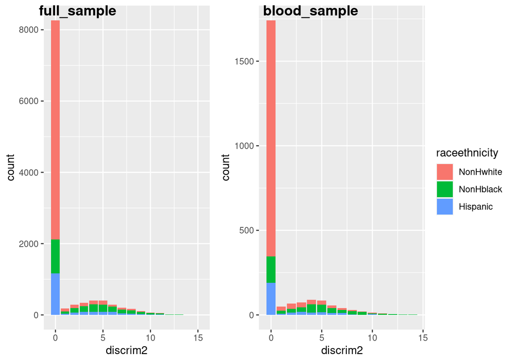

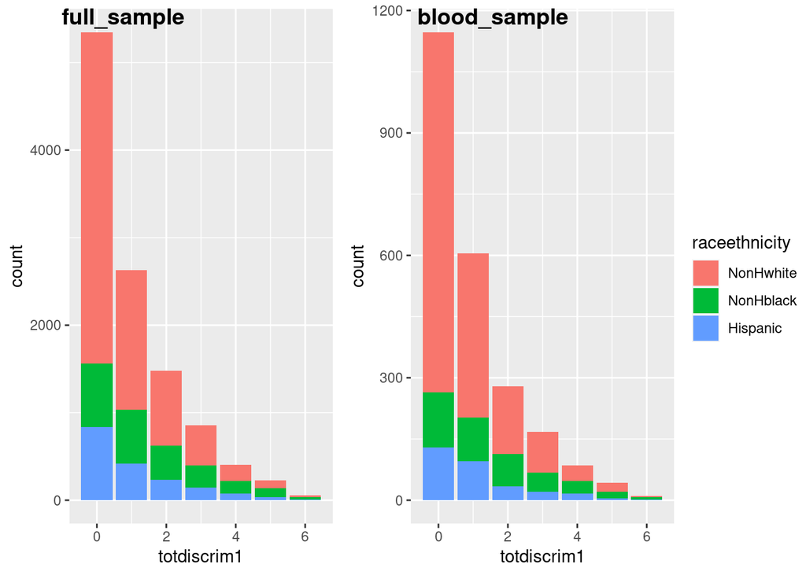

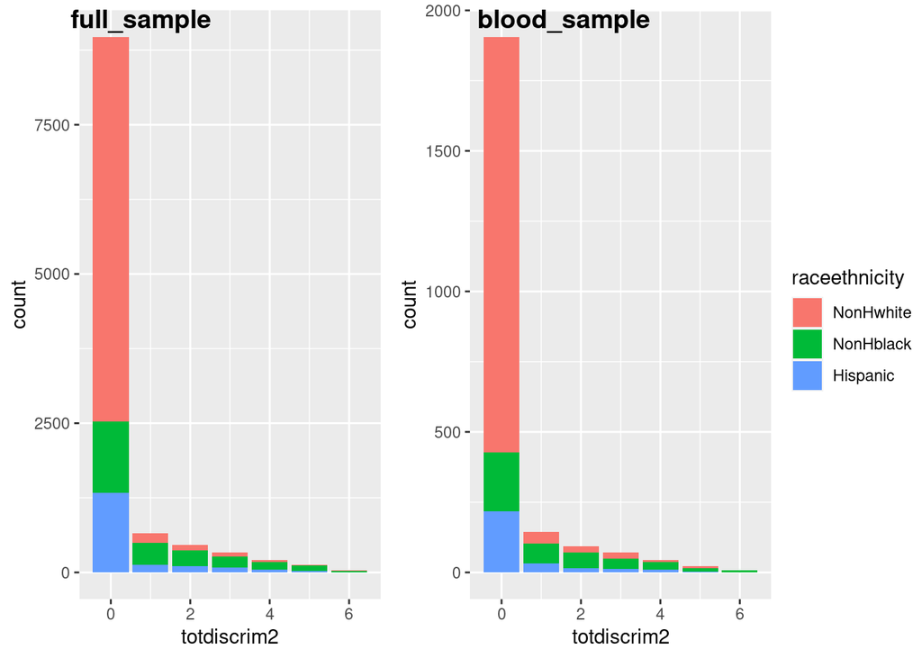

## whole sample white black and white hispanic 2 sample Wilcoxon test p value

```
##                    discrim1      discrim2  totdiscrim1   totdiscrim2
## white_black    6.644365e-51  0.000000e+00 1.454396e-91  0.000000e+00
## white_hispanic 3.625787e-03 4.811366e-126 1.238850e-08 2.697496e-107
```

## whole sample white black and white hispanic 2 sample chisquare test p value

```
##                lowbirthweight high_lowbirth
## white_black      4.242360e-26     0.4615921
## white_hispanic   2.065206e-01     0.3901690
```

## blood sample white black and white hispanic 2 sample Wilcoxon test p value

```
##                    discrim1      discrim2  totdiscrim1   totdiscrim2
## white_black    6.846611e-17 1.448341e-115 1.595072e-23 1.095643e-108
## white_hispanic 1.278533e-01  1.327594e-25 2.749701e-04  1.043014e-24
```

## blood sample white black and white hispanic 2 sample chisquare test p value

```
##                lowbirthweight high_lowbirth
## white_black      2.770003e-05     0.3444492
## white_hispanic   1.770216e-01     0.4176843
```

## freq distribution of discrim1, discrim2, totdiscrim1, totdiscrim2, discrimwhy for blood sample

### discrim1 is the sum of 5 types of discrimination H5MN5[A-E]

- H5MN5[A-E], each range of 0:3, never(0), rarely(1), sometimes(2), often(3)

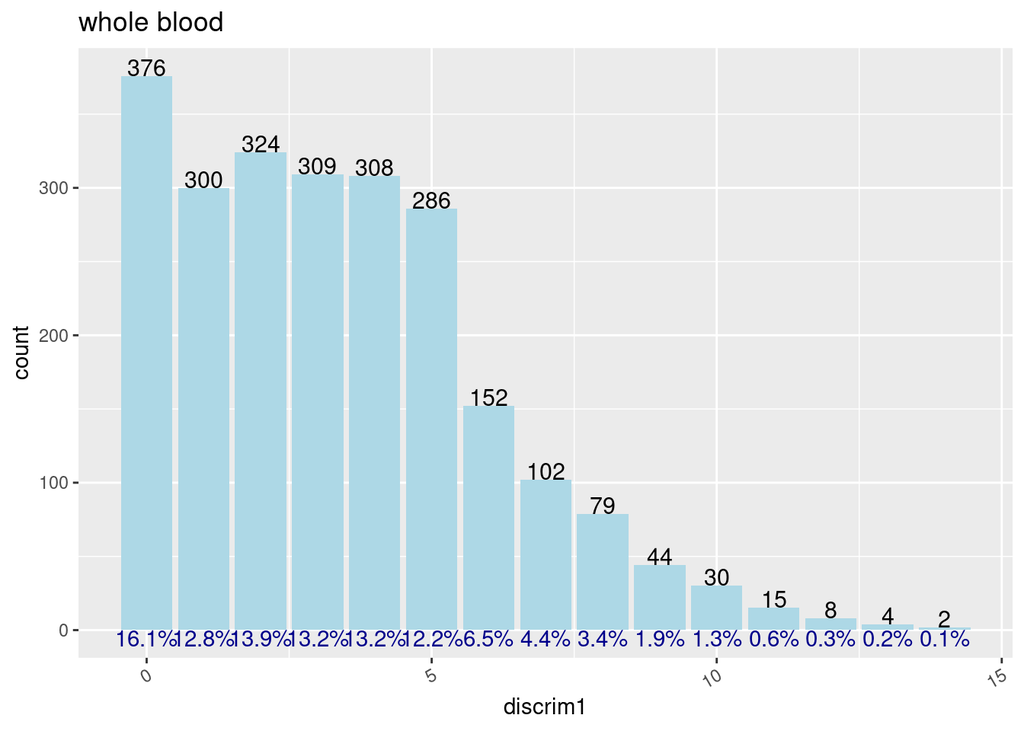

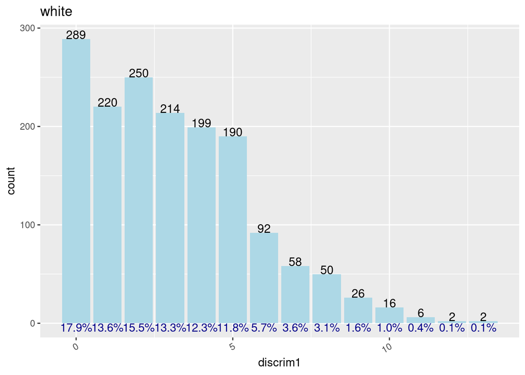

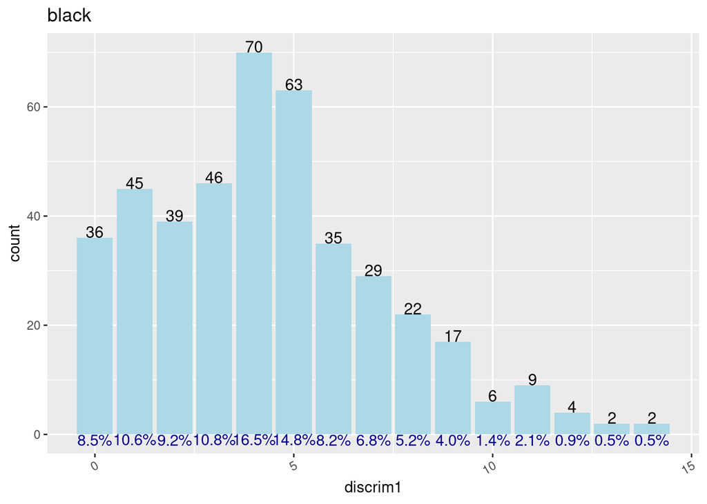

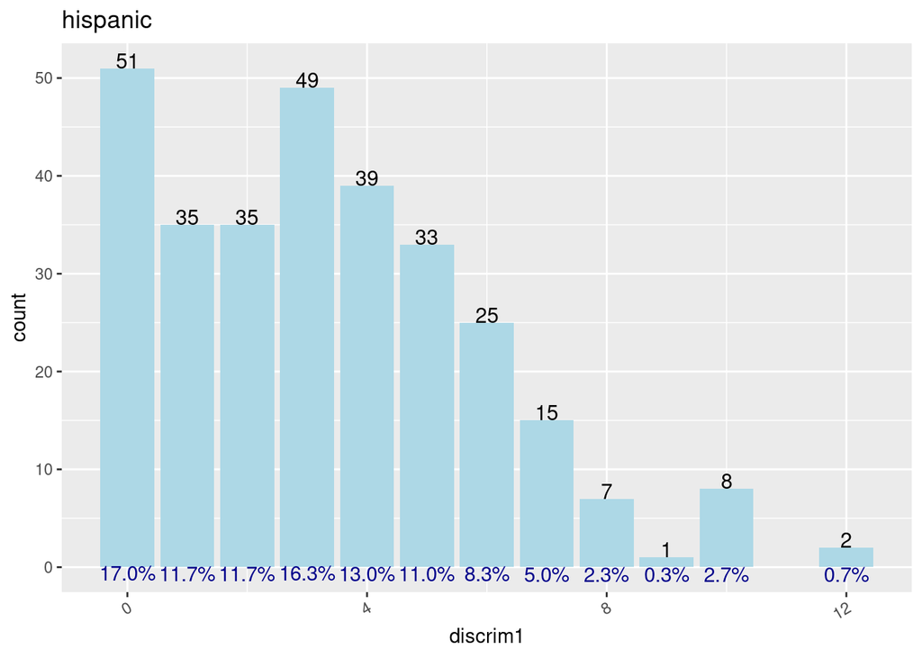

### discrim2 equals discrim1 if they feel the discrimination were due to race and ethnicity, otherwise 0

- discrimination due to race and ethnicity: H5MN6A==1 (ancestry or national origin) or H5MN6D==1(race)
- discrim2 ==0 : either they do not feel any discrimination or they do not think the discrimination were due to race and ethnicity

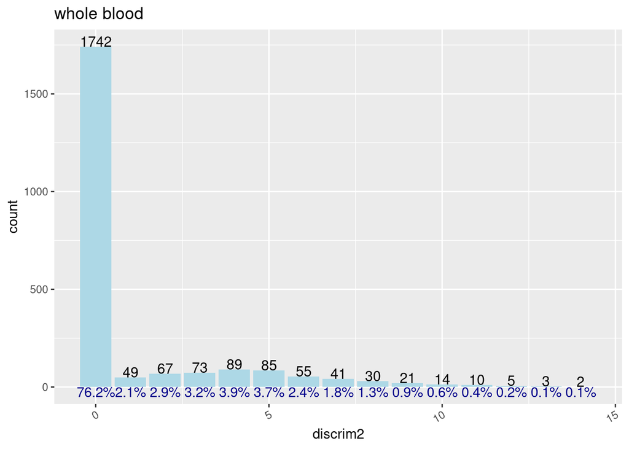

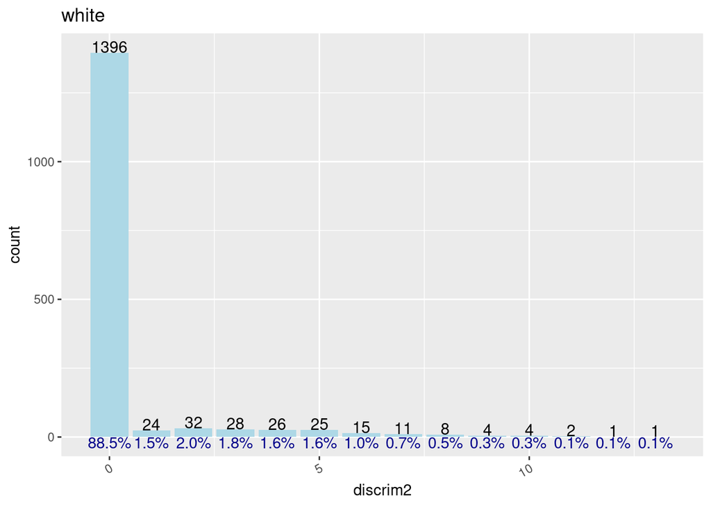

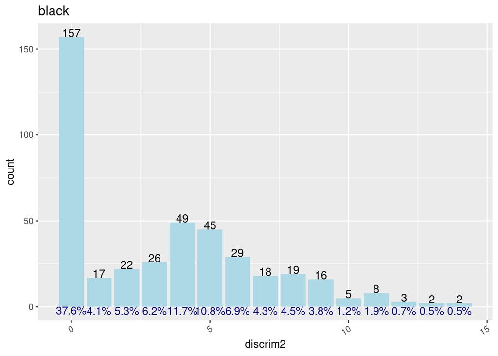

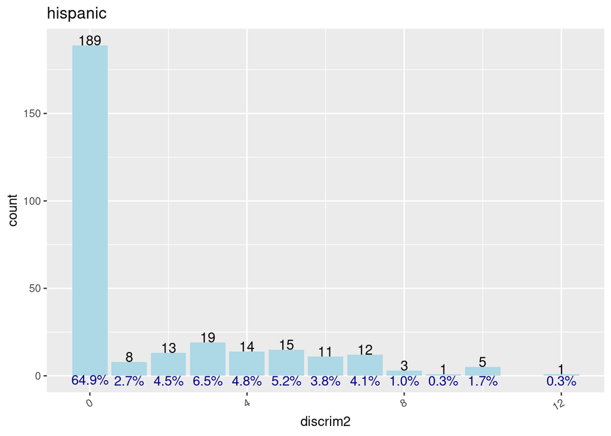

### totdiscrim1 is the sum of H5MN5[A-E] and H5MN7(binary)

- here H5MN5[A-E] are binarized: 0 for never and rarely, 1 for sometimes and often

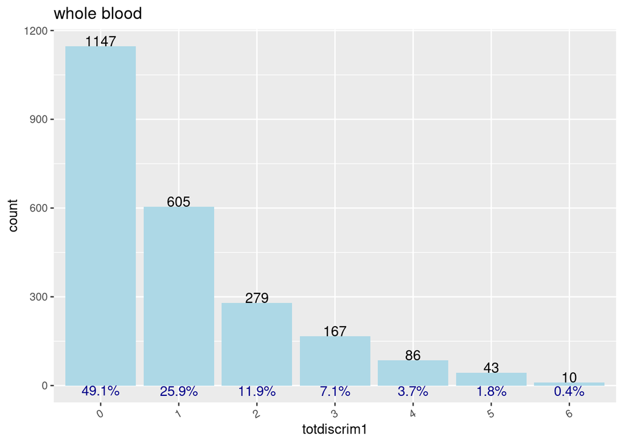

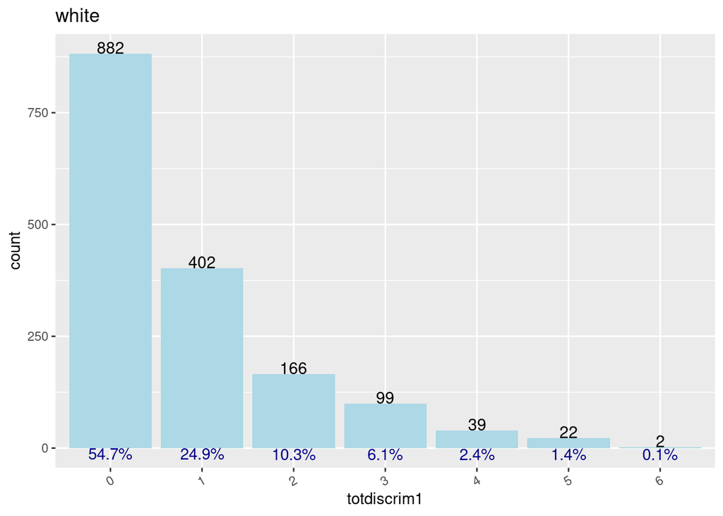

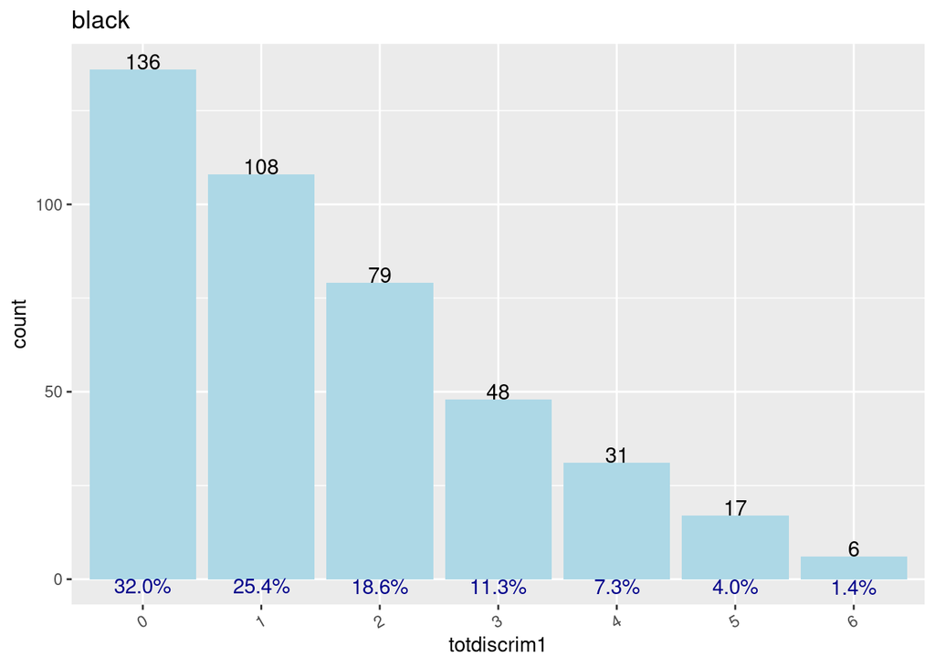

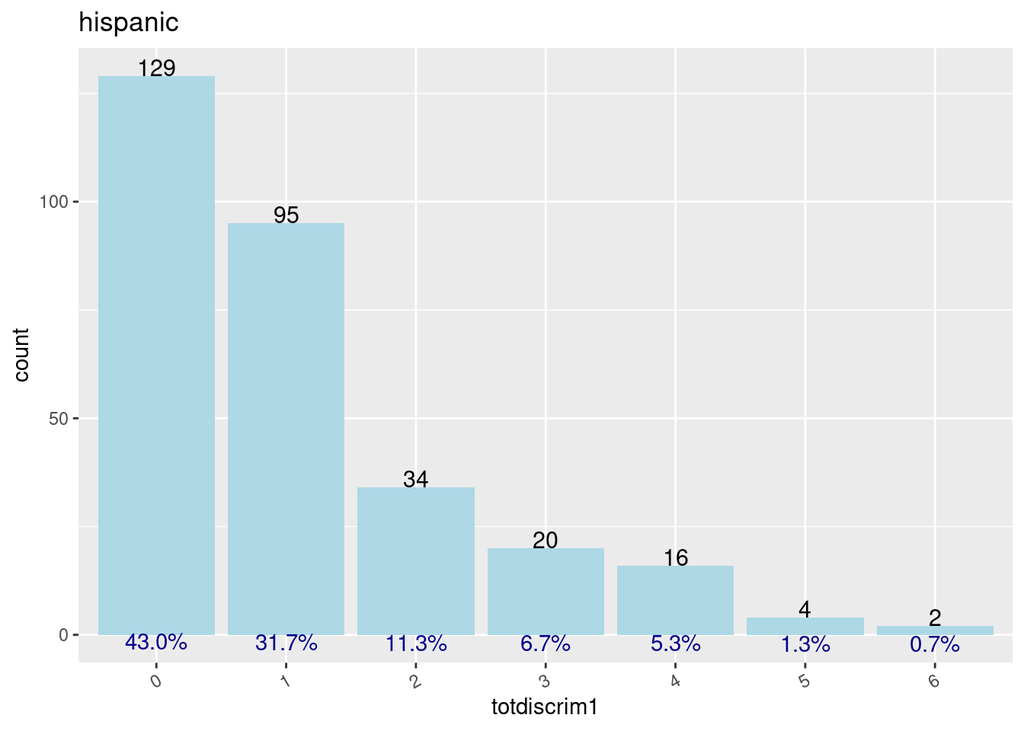

### totdiscrim2 equals totdiscrim1 if they feel the discrimination were due to race and ethnicity, otherwise 0

- discrimination due to race and ethnicity: H5MN6A==1 (ancestry or national origin) or H5MN6D==1(race)
- discrim2 ==0 : either they do not feel any discrimination or they do not think the discrimination were due to race and ethnicity

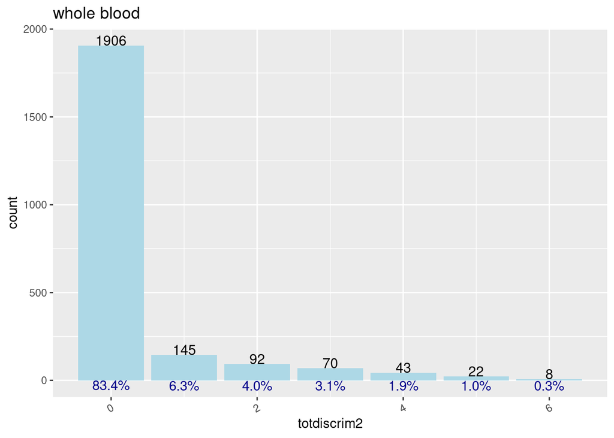

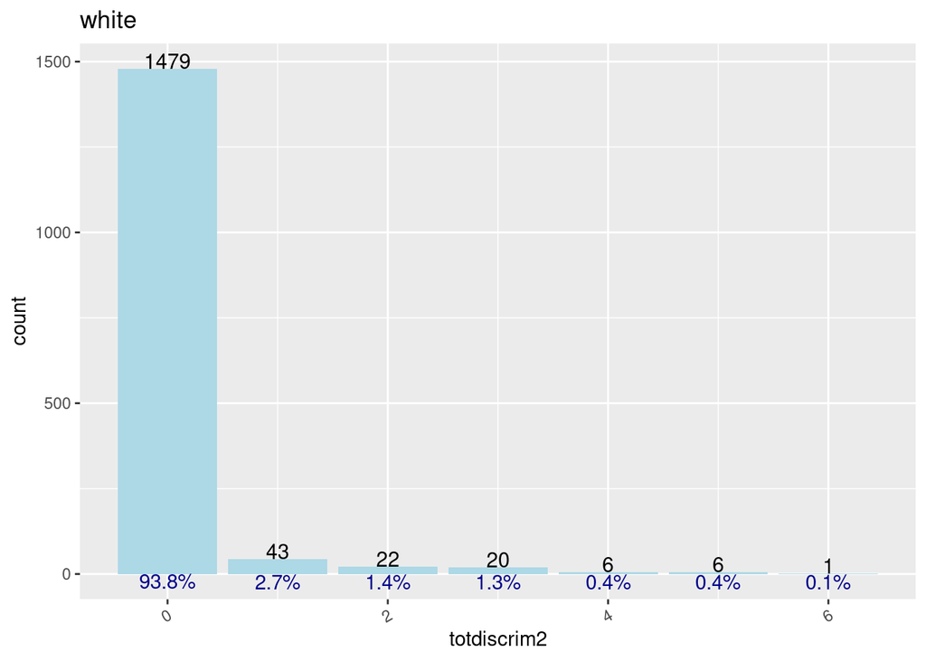

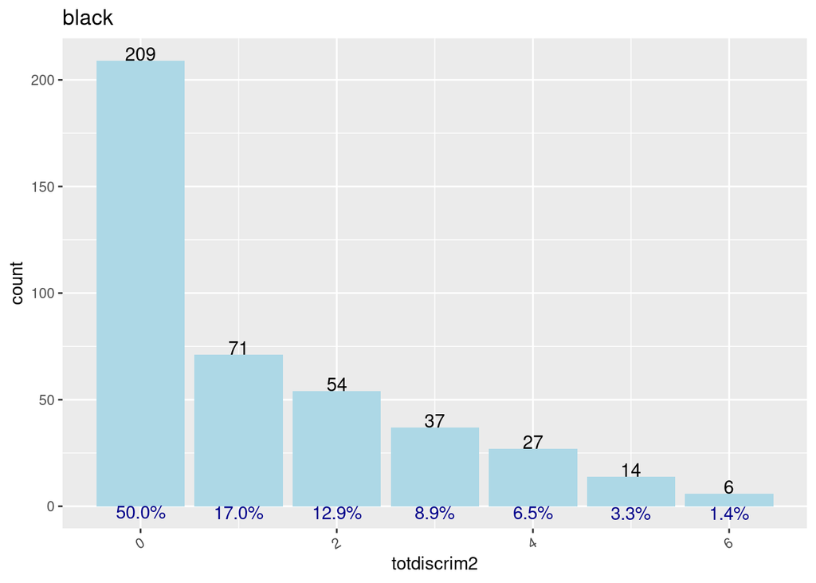

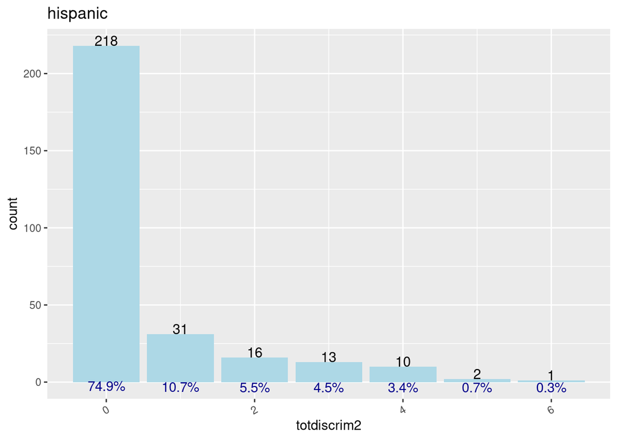

### countdiscrimwhy is created: if totdiscrim1>0, sum “H5MN6[A-L]” (reasons of discrimination)

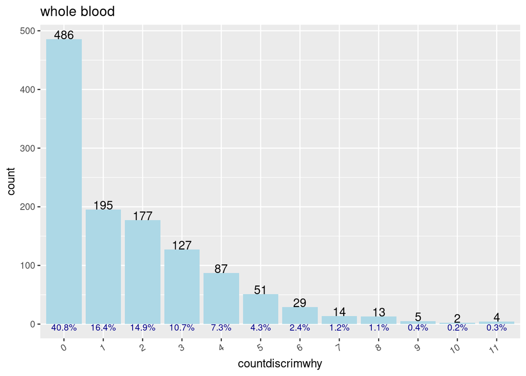

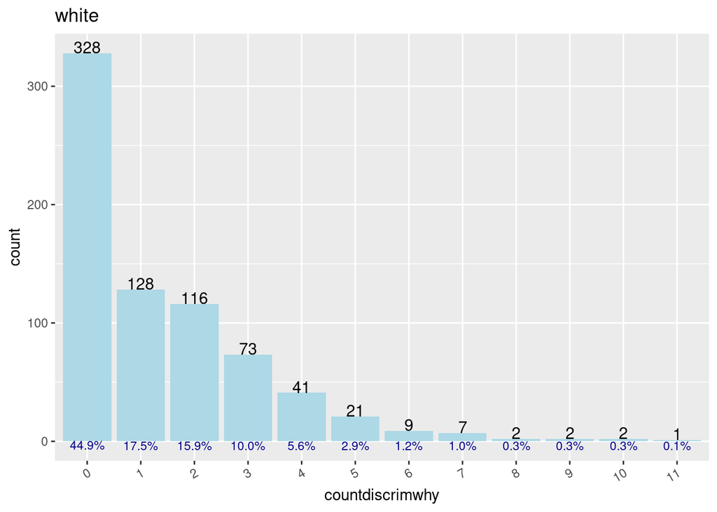

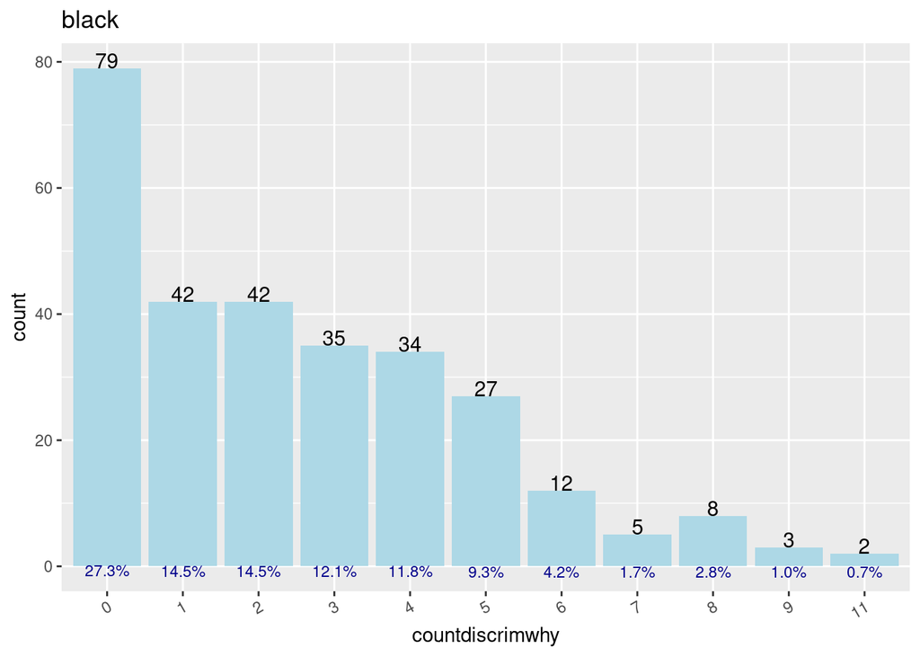

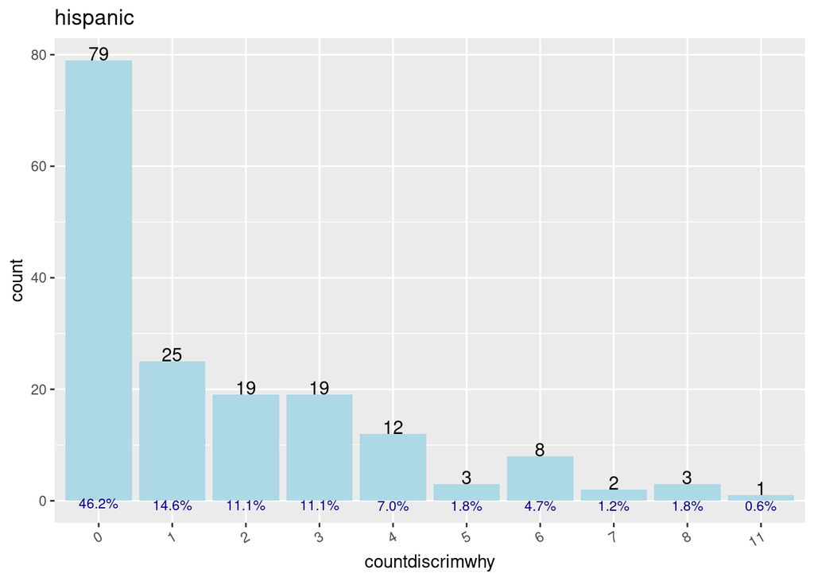